# ForestSearch Scenario Validation Suite

- Show All Code
- Hide All Code
- View Source

End-to-End Simulation Tests for All Search Configurations

Author

Larry F. León

Published

April 10, 2026

# 1 Purpose

Each scenario plants a known subgroup Q and confirms that ForestSearch:

1. **Detects Q** under H1 (detection rate > 50%)
2. **Controls FPR** under H0 (false positive rate < 15%)

## 1.1 Null DGM Design

The null hypothesis in ForestSearch is **no treatment effect heterogeneity** (no HTE). This does NOT mean zero treatment effect. Under H0, everyone receives a homogeneous (generally beneficial) treatment effect – there is no subgroup with a different treatment effect.

FPR depends on the **gap between the null ITT effect and the screening threshold**. When this gap is small, random sampling variability pushes some subgroup estimates above the threshold, inflating FPR. This is expected statistical behaviour, not a sign convention error.

For clean validation of **sign conventions**, null outcomes use homogeneous beneficial treatment effects. The null ITT effect for each scenario is reported in the results table.

Note: for **benefit + adverse** scenarios (S4, S9), switching treatment labels inverts the ITT. A beneficial treatment with OR = 0.7 on the original scale becomes OR = 1/0.7 = 1.43 on the switched scale. A **stronger** beneficial treatment produces a **higher** switched-scale effect, **closer to** (or above) the screening threshold. This is the opposite of harm search scenarios where a stronger beneficial treatment pushes the effect further below threshold.

Therefore, benefit + adverse null DGMs must use **weaker** treatment effects than other scenarios:

- **Harm search** null: strong benefit is fine (OR << 1 is far below threshold > 1)
- **Benefit + positive** null: strong benefit is fine (switched-scale OR << 1 is far below threshold)
- **Benefit + adverse** null: weak benefit required (OR close to 1 → switched OR close to 1 → below threshold)

The `k_treat` parameter in `generate_aft_dgm_flex()` (and the analogous parameter in `generate_glm_dgm()`) can attenuate the fitted treatment coefficient to achieve this.

## 1.2 Implementation Details

The table below shows how each scenario maps to ForestSearch parameters. The **Null ITT** column always reports the effect of the **original treatment** on the **original outcome** — the clinical interpretation. Internally, ForestSearch may operate on a manipulated scale (negated Y or switched treatment), but the ITT is always translated back.

**Interpretation of Null ITT values:**

- **Adverse outcomes** (events, pain, hazard): beneficial treatment produces OR/IRR/HR < 1 or MD < 0. Treatment *reduces* the bad outcome.
- **Positive outcomes** (improvement, CD4): beneficial treatment produces OR > 1 or MD > 0. Treatment *increases* the good outcome.

```r
impl <- data.frame(
  Scenario = paste0("S", 1:10),
  Search = c("Harm","Harm","Benefit","Benefit",
             "Harm","Harm","Benefit","Harm","Benefit","Benefit"),
  Outcome = c("Adverse","Positive","Positive","Adverse",
              "Adverse","Positive","Positive","Adverse","Adverse",
              "Positive"),
  Endpoint = c("Binary","Binary","Binary","Binary",
               "Continuous","Continuous","Continuous","Count",
               "Survival","Survival"),
  Y_used = c(
    "Y (events)",
    "1 - Y (failure)",
    "Y (improvement)",
    "Y (events)",
    "Y (pain score)",
    "-Y (negated CD4)",
    "Y (CD4 change)",
    "Y (event count)",
    "time / event",
    "time / event"
  ),
  Treat_used = c(
    "Original", "Original", "Switched", "Switched",
    "Original", "Original", "Switched", "Original",
    "Switched", "Original"
  ),
  FS_searches_for = c(
    "OR >= c1",
    "OR >= c1",
    "OR >= c1",
    "OR >= c1",
    "MD >= c1",
    "MD >= c1",
    "MD >= c1",
    "IRR >= c1",
    "HR >= c1",
    "HR >= c1"
  ),
  Null_ITT = c(
    "OR < 1 (reduces events)",
    "OR > 1 (increases improvement)",
    "OR > 1 (increases improvement)",
    "OR < 1 (reduces events)",
    "MD < 0 (reduces pain)",
    "MD > 0 (increases CD4)",
    "MD > 0 (increases CD4)",
    "IRR < 1 (reduces rate)",
    "HR < 1 (delays adverse event)",
    "HR > 1 (accelerates recovery)"
  ),
  stringsAsFactors = FALSE
)

impl |>
  gt::gt() |>
  gt::tab_header(
    title = "Scenario Implementation Details",
    subtitle = paste(
      "How each search goal maps to ForestSearch parameters.",
      "Null ITT always reported as original treatment effect",
      "on original outcome.")
  ) |>
  gt::cols_label(
    Y_used = "Outcome Used by FS",
    Treat_used = "Treatment Used by FS",
    FS_searches_for = "FS Searches For",
    Null_ITT = "Null ITT (Original Treatment)"
  ) |>
  gt::tab_style(
    style = gt::cell_fill(color = "#e8f5e9"),
    locations = gt::cells_body(
      columns = "Null_ITT")
  ) |>
  gt::tab_style(
    style = gt::cell_fill(color = "#fff3e0"),
    locations = gt::cells_body(rows = c(4, 9))
  ) |>
  gt::tab_footnote(
    footnote = paste(
      "Benefit + adverse scenarios (S4, S9): switching treatment",
      "inverts the beneficial ITT on the search scale, placing it",
      "closer to the threshold. These use higher thresholds (2.0)."),
    locations = gt::cells_body(columns = "Treat_used",
                           rows = c(4, 9))
  )
```

Table 1

Scenario Implementation Details

How each search goal maps to ForestSearch parameters. Null ITT always reported as original treatment effect on original outcome.

| Scenario | Search | Outcome | Endpoint | Outcome Used by FS | Treatment Used by FS | FS Searches For | Null ITT (Original Treatment) |
| --- | --- | --- | --- | --- | --- | --- | --- |
| S1 | Harm | Adverse | Binary | Y (events) | Original | OR >= c1 | OR < 1 (reduces events) |
| S2 | Harm | Positive | Binary | 1 - Y (failure) | Original | OR >= c1 | OR > 1 (increases improvement) |
| S3 | Benefit | Positive | Binary | Y (improvement) | Switched | OR >= c1 | OR > 1 (increases improvement) |
| S4 | Benefit | Adverse | Binary | Y (events) | Switched<sup>1</sup> | OR >= c1 | OR < 1 (reduces events) |
| S5 | Harm | Adverse | Continuous | Y (pain score) | Original | MD >= c1 | MD < 0 (reduces pain) |
| S6 | Harm | Positive | Continuous | -Y (negated CD4) | Original | MD >= c1 | MD > 0 (increases CD4) |
| S7 | Benefit | Positive | Continuous | Y (CD4 change) | Switched | MD >= c1 | MD > 0 (increases CD4) |
| S8 | Harm | Adverse | Count | Y (event count) | Original | IRR >= c1 | IRR < 1 (reduces rate) |
| S9 | Benefit | Adverse | Survival | time / event | Switched<sup>1</sup> | HR >= c1 | HR < 1 (delays adverse event) |
| S10 | Benefit | Positive | Survival | time / event | Original | HR >= c1 | HR > 1 (accelerates recovery) |

<sup>1</sup> Benefit + adverse scenarios (S4, S9): switching treatment inverts the beneficial ITT on the search scale, placing it closer to the threshold. These use higher thresholds (2.0).

## 1.3 Detailed Scenario Explanations

ForestSearch always searches for subgroups where the effect estimate exceeds a threshold: $\hat{\theta}(S) \geq c_1$. This comparison never changes. All scenario setup reduces to orienting the data so the target subgroup produces $\hat{\theta} > 0$. Below is a detailed walkthrough of each scenario, explaining *why* each manipulation is needed and *how* to interpret the resulting estimates.

### 1.3.1 Harm Search Scenarios (S1, S2, S5, S6, S8)

In a harm search, we want to find subgroups where treatment causes worse outcomes. Treatment is generally beneficial (the overall ITT favours treatment), but some patients may be harmed.

- **S1 (Harm + Adverse Binary, direct).** The outcome Y = 1 represents an adverse event (e.g., death, recurrence). Treatment reduces events overall (OR < 1), but in the harm subgroup Q, treatment *increases* events (OR > 1 in Q). Since “higher Y = worse” and “treatment increases Y for Q,” the effect estimate in Q naturally exceeds the threshold. **No manipulation needed.**
- **S2 (Harm + Positive Binary, negate Y).** The outcome Y = 1 represents improvement (positive). Treatment increases improvement overall, but in Q, treatment *reduces* improvement. The problem: a reduced positive outcome gives OR < 1 in Q, which fails the $\hat{\theta} \geq c_1$ check. **Fix:** Define a new outcome $Y' = 1 - Y$ (failure). Now treatment increasing failure for Q gives OR($Y'$) > 1 in Q. The **Null ITT** is reported on the original scale (improvement): OR > 1 means treatment increases improvement. The DGM operates on the failure scale $Y'$, so its reported OR is on the failure scale.
- **S5 (Harm + Adverse Continuous, direct).** Y is a continuous adverse outcome (e.g., pain score; higher = worse). Treatment reduces pain overall (MD < 0), but in Q, treatment increases pain (MD > 0). Naturally exceeds the threshold. **No manipulation needed.**
- **S6 (Harm + Positive Continuous, negate Y).** Y is a positive outcome (e.g., CD4 count; higher = better). Treatment increases CD4 overall, but in Q, treatment reduces CD4. A negative MD fails the threshold. **Fix:** Use $Y' = -Y$ (negated). Now treatment increasing the negated outcome for Q gives MD > 0. The Null ITT is reported on the original (positive) scale: MD > 0 means treatment increases CD4.
- **S8 (Harm + Adverse Count, direct).** Y is an adverse event count (e.g., number of infections). Treatment reduces the rate overall (IRR < 1), but in Q, treatment increases it (IRR > 1). Naturally exceeds the threshold. **No manipulation needed.**

### 1.3.2 Benefit Search Scenarios (S3, S4, S7, S9, S10)

In a benefit search, we want to find subgroups where treatment helps *more* than average. Treatment is generally beneficial, and the benefit subgroup Q has amplified benefit.

- **S3 (Benefit + Positive Binary, switch treatment).** Y = 1 represents improvement. Treatment increases improvement for everyone, but Q improves *more*. The problem: the benefit subgroup has OR > 1, but so does everyone — there is no contrast. **Fix:** Switch treatment labels (treat $\leftarrow$ 1 - treat). Under switched labels, the “treatment” (actually control) *decreases* improvement for Q relative to the original treatment. On the switched scale, OR > 1 in Q indicates that the switched “treatment” increases outcome — equivalently, the *original* treatment helps Q more. The Null ITT is reported on the original scale: OR > 1 means treatment increases improvement.
- **S4 (Benefit + Adverse Binary, switch treatment).** Y = 1 represents an adverse event. Treatment reduces events for Q more than for others (stronger benefit). **Fix:** Switch treatment labels. Under switched labels, the “treatment” (actually control) increases events for Q, giving OR > 1 on the switched scale. **FPR challenge:** A beneficial treatment with OR = 0.7 gives OR$_\text{sw}$ = 1/0.7 = 1.43. This is inherently close to the threshold. With binary data in small subgroups (~75 per arm), SD(log OR) $\approx$ 0.33, and multiplicity across ~21 candidates pushes estimates above threshold. This scenario requires near-zero null treatment effect for clean FPR validation.
- **S7 (Benefit + Positive Continuous, switch treatment).** Y is a positive outcome (CD4). Treatment increases CD4 for everyone, but Q benefits more. **Fix:** Switch treatment labels. Under switched labels, the “treatment” (control) produces lower CD4 for Q than the original treatment, giving positive MD on the switched scale. The Null ITT is reported on the original scale: MD > 0 means treatment increases CD4.
- **S9 (Benefit + Adverse Survival, switch treatment).** Time-to-event with adverse event (death). Treatment delays the adverse event (HR < 1 on original scale, i.e., beneficial). Q benefits *more* from treatment. **Fix:** Switch treatment labels. Under switched labels, the “treatment” (control) accelerates events for Q, giving HR > 1 on the switched scale. The Null ITT is reported on the original scale: HR < 1 means treatment delays the adverse event. **FPR challenge:** Same inversion issue as S4. Uses `k_treat` to attenuate the null treatment effect.
- **S10 (Benefit + Positive Survival, direct).** Time-to-event with positive event (recovery). Treatment accelerates recovery (HR > 1 on original scale, i.e., beneficial). Q recovers even faster under treatment. Since HR > 1 naturally exceeds the threshold, **no manipulation needed.** This is the mirror image of S9 and demonstrates that the beneficial direction of HR depends on whether the event is adverse or positive.

# 2 Setup

```r
library(forestsearch)
library(survival)
library(speff2trial)
library(data.table)
library(ggplot2)
library(gt)
library(doFuture)
library(foreach)

plan(multisession, workers = n_workers)
cat("Workers:", n_workers, "\n")
```

```
#> Workers: 115
```

```r
collect_results <- function(raw_list, label = "") {
  is_err <- vapply(raw_list, inherits, logical(1), "error")
  if (sum(is_err) > 0)
    warning(sprintf("%s: %d of %d tasks failed.", label,
                    sum(is_err), length(raw_list)))
  good <- raw_list[!is_err]
  if (length(good) == 0) return(data.frame())
  as.data.frame(data.table::rbindlist(good, use.names = TRUE, fill = TRUE))
}

run_scenario_sims <- function(dgm, nsims, confounders, fs_params, label) {
  cat(sprintf("  Running %d sims (%s)...\n", nsims, label))
  t0 <- proc.time()[3]
  raw <- foreach(
    sim = seq_len(nsims), .errorhandling = "pass",
    .options.future = list(
      packages = c("forestsearch","survival","data.table","future"),
      seed = TRUE)
  ) %dofuture% {
    future::plan("sequential")
    run_simulation_analysis(
      sim_id = sim, dgm = dgm, n_sample = sim_n_sample,
      confounders_base = confounders, n_add_noise = 0L,
      run_fs = TRUE, run_fs_grf = FALSE, run_grf = FALSE,
      fs_params = fs_params, verbose = FALSE)
  }
  elapsed <- proc.time()[3] - t0
  results <- collect_results(raw, label)
  n_err <- sum(vapply(raw, inherits, logical(1), "error"))
  det <- if (nrow(results) > 0 && "any.H" %in% names(results))
    100 * mean(results$any.H[results$analysis == "FS"], na.rm = TRUE)
  else NA_real_
  cat(sprintf("  %s: %.1f%% detection, %d failed, %.1f sec\n",
      label, det, n_err, elapsed))
  list(results = results, detection = det, n_failed = n_err,
       elapsed = elapsed, label = label)
}

base_fs_params <- list(
  outcome.name = "y_sim", event.name = "y_sim",
  treat.name = "treat_sim", id.name = "id",
  use_lasso = FALSE, use_grf = TRUE,
  fs.splits = fs_splits, n.min = n_min,
  d0.min = d0_min, d1.min = d1_min,
  maxk = maxk, vi.grf.min = vi_grf_min, seedit = sim_seed,
  pconsistency.threshold = pcons,
  parallel_args = list(plan = "sequential", workers = 1,
                        show_message = FALSE))

master_results <- data.frame(
  Scenario = character(0), Search = character(0),
  Outcome_Type = character(0), Endpoint = character(0),
  Manipulation = character(0), Null_ITT = character(0),
  Det_H1 = numeric(0), FPR_H0 = numeric(0),
  Status = character(0), stringsAsFactors = FALSE)

timing_log <- data.frame(
  Scenario = character(0), Endpoint = character(0),
  nsims_H1 = integer(0), nsims_H0 = integer(0),
  time_H1 = numeric(0), time_H0 = numeric(0),
  per_sim_H1 = numeric(0), per_sim_H0 = numeric(0),
  stringsAsFactors = FALSE)

record <- function(scenario, search, otype, endpoint, manip,
                   null_itt, det, fpr,
                   r_alt_obj = NULL, r_null_obj = NULL) {
  status <- if (is.na(det) || is.na(fpr)) "ERROR"
    else if (det >= 50 && fpr <= 15) "PASS"
    else if (det >= 30 && fpr <= 20) "MARGINAL"
    else "FAIL"
  master_results[nrow(master_results) + 1, ] <<- data.frame(
    Scenario = scenario, Search = search, Outcome_Type = otype,
    Endpoint = endpoint, Manipulation = manip,
    Null_ITT = null_itt,
    Det_H1 = round(det, 1), FPR_H0 = round(fpr, 1),
    Status = status, stringsAsFactors = FALSE)
  # Accumulate timing
  if (!is.null(r_alt_obj) && !is.null(r_null_obj)) {
    t_h1 <- r_alt_obj$elapsed
    t_h0 <- r_null_obj$elapsed
    n_h1 <- nsims_alt
    n_h0 <- nsims_null
    timing_log[nrow(timing_log) + 1, ] <<- data.frame(
      Scenario = scenario, Endpoint = endpoint,
      nsims_H1 = n_h1, nsims_H0 = n_h0,
      time_H1 = round(t_h1, 1), time_H0 = round(t_h0, 1),
      per_sim_H1 = round(t_h1 / n_h1, 3),
      per_sim_H0 = round(t_h0 / n_h0, 3),
      stringsAsFactors = FALSE)
  }
}
```

# 3 Synthetic Data

```r
set.seed(42)
syn <- data.frame(
  id = seq_len(N_syn), treat = rep(0:1, each = N_syn / 2),
  z1 = as.factor(sample(0:1, N_syn, TRUE)),
  z2 = as.factor(sample(0:1, N_syn, TRUE)),
  z3 = as.factor(sample(0:1, N_syn, TRUE)),
  z4 = as.factor(sample(0:1, N_syn, TRUE)))
in_Q <- syn$z1 == 1 & syn$z2 == 1
syn$treat_sw <- 1L - syn$treat
syn$fu <- rep(1, N_syn)
cat(sprintf("Synthetic: N=%d, Q prevalence=%.1f%%\n",
    N_syn, 100 * mean(in_Q)))
```

```
#> Synthetic: N=1200, Q prevalence=25.0%
```

```r
# -- ALT outcomes (treatment beneficial overall, REVERSED for Q) ------------
# In real trials, treatment helps overall. The harm subgroup Q is
# where the general benefit reverses. The benefit subgroup Q is
# where the general benefit is amplified.

# S1: Harm + adverse binary. Treatment REDUCES events overall,
#     but INCREASES events for Q (harm subgroup).
syn$y_adverse_bin_alt <- rbinom(N_syn, 1,
  ifelse(syn$treat == 1 & in_Q, 0.65,        # treat HURTS Q
    ifelse(syn$treat == 1, 0.22, 0.35)))      # treat HELPS everyone else

# S3: Benefit + positive binary. Treatment INCREASES improvement
#     overall, with AMPLIFIED benefit for Q.
syn$y_positive_bin_alt <- rbinom(N_syn, 1,
  ifelse(syn$treat == 1 & in_Q, 0.80,        # treat HELPS Q even more
    ifelse(syn$treat == 1, 0.50, 0.40)))      # treat helps everyone

syn$y_adverse_cont_alt <- 50 - 5 * syn$treat + rnorm(N_syn, sd = 15)
syn$y_adverse_cont_alt[in_Q & syn$treat == 1] <-
  syn$y_adverse_cont_alt[in_Q & syn$treat == 1] + 30   # reverses for Q

syn$y_positive_cont_alt <- 200 + 8 * syn$treat + rnorm(N_syn, sd = 40)
syn$y_positive_cont_alt[in_Q & syn$treat == 1] <-
  syn$y_positive_cont_alt[in_Q & syn$treat == 1] + 50  # amplified for Q

# Count: treatment reduces rate overall, increases for Q
lambda_alt <- exp(0.5 - 0.15 * syn$treat)              # treat reduces rate
lambda_alt[in_Q & syn$treat == 1] <-
  lambda_alt[in_Q & syn$treat == 1] * 4                 # except Q
syn$y_adverse_ct_alt <- rpois(N_syn, lambda_alt)

# S2: harm + positive binary (negate Y).
# Treatment increases improvement overall, but REDUCES it for Q.
# After negation, treatment reduces failure overall, increases for Q.
syn$y_s2_alt <- 1L - rbinom(N_syn, 1,
  ifelse(syn$treat == 1 & in_Q, 0.15,        # treat hurts Q (low improve)
    ifelse(syn$treat == 1, 0.55, 0.40)))      # treat helps everyone else

# S4: benefit + adverse binary (switch treat).
# Treatment reduces events for Q (benefit).
syn$y_s4_alt <- rbinom(N_syn, 1,
  ifelse(syn$treat == 1 & in_Q, 0.10,        # treat strongly helps Q
    ifelse(syn$treat == 1, 0.33, 0.38)))      # treat mildly helps everyone

# S6: harm + positive continuous (negate Y).
# Treatment increases CD4 overall but reduces it for Q.
syn$y_s6_alt <- -(200 + 8 * syn$treat + rnorm(N_syn, sd = 40))
syn$y_s6_alt[in_Q & syn$treat == 1] <-
  syn$y_s6_alt[in_Q & syn$treat == 1] + 50   # reverses for Q on negated scale

# -- NULL outcomes (homogeneous beneficial treatment, NO HTE) ---------------
# Treatment is clearly beneficial for everyone equally.
# Under the null, the search-scale effect is far from the threshold.

# Binary adverse null: treatment reduces events (OR_adverse < 1)
syn$y_adverse_bin_null <- rbinom(N_syn, 1,
  ifelse(syn$treat == 1, 0.22, 0.35))         # OR_adv ~ 0.52

# Binary positive null: treatment increases improvement (OR_pos > 1)
syn$y_positive_bin_null <- rbinom(N_syn, 1,
  ifelse(syn$treat == 1, 0.55, 0.40))         # OR_pos ~ 1.83

# Continuous adverse null: treatment reduces pain
syn$y_adverse_cont_null <- 50 - 5 * syn$treat + rnorm(N_syn, sd = 15)

# Continuous positive null: treatment increases CD4
syn$y_positive_cont_null <- 200 + 8 * syn$treat + rnorm(N_syn, sd = 40)

# Count adverse null: treatment reduces event rate
syn$y_adverse_ct_null <- rpois(N_syn, exp(0.5 - 0.15 * syn$treat))

# S2 null (failure scale): treatment reduces failure
syn$y_s2_null <- 1L - rbinom(N_syn, 1,
  ifelse(syn$treat == 1, 0.55, 0.40))         # OR_fail ~ 0.55

# S4 null (adverse, switched scale):
# CRITICAL: for benefit + adverse with switched treatment, the
# switched-scale OR = 1/OR_orig.
# With binary data in small subgroups (~75 per arm), the SD of
# log(OR) is ~0.33. With ~21 candidates (maxk=2), multiplicity
# means even OR_sw = 1.15 produces 30%+ FPR.
# Use near-zero treatment effect for clean FPR validation.
syn$y_s4_null <- rbinom(N_syn, 1,
  ifelse(syn$treat == 1, 0.395, 0.40))         # OR_orig ~ 0.98 -> OR_sw ~ 1.02

# S6 null (negated continuous): treatment increases CD4
syn$y_s6_null <- -(200 + 8 * syn$treat + rnorm(N_syn, sd = 40))

# S10: Benefit + Positive Survival (direct, no switching)
# Positive event (e.g., recovery): treatment ACCELERATES it → HR > 1
# Use mild null treatment effect so HR(null) is well below threshold.
# Alt: Q recovers even faster under treatment
rate_s10_base <- 0.05
rate_s10_alt <- rate_s10_base * exp(0.15 * syn$treat)
rate_s10_alt[in_Q & syn$treat == 1] <-
  rate_s10_alt[in_Q & syn$treat == 1] * 3
syn$time_s10_alt <- rexp(N_syn, rate_s10_alt)
syn$event_s10_alt <- 1L
syn$event_s10_alt[syn$time_s10_alt > 60] <- 0L
syn$time_s10_alt <- pmin(syn$time_s10_alt, 60)

# Null: homogeneous mild recovery acceleration (HR ~ 1.16)
rate_s10_null <- rate_s10_base * exp(0.15 * syn$treat)
syn$time_s10_null <- rexp(N_syn, rate_s10_null)
syn$event_s10_null <- 1L
syn$event_s10_null[syn$time_s10_null > 60] <- 0L
syn$time_s10_null <- pmin(syn$time_s10_null, 60)

# -- Report null ITT effects (ORIGINAL treatment scale) --------------------
# For switched scenarios, report effect of the ORIGINAL treatment.
cat("\nNull ITT effects (original treatment, homogeneous, no HTE):\n")
```

```
#>
#> Null ITT effects (original treatment, homogeneous, no HTE):
```

```r
safe_or <- function(y, w) {
  t <- table(y, w); (t[2,2]*t[1,1]) / (t[1,2]*t[2,1])
}
cat(sprintf("  S1 Binary adverse:      OR = %.2f (treat reduces events)\n",
    safe_or(syn$y_adverse_bin_null, syn$treat)))
```

```
#>   S1 Binary adverse:      OR = 0.54 (treat reduces events)
```

```r
cat(sprintf("  S2 Binary pos (negated): OR = %.2f (treat increases improvement)\n",
    1 / safe_or(syn$y_s2_null, syn$treat)))
```

```
#>   S2 Binary pos (negated): OR = 1.86 (treat increases improvement)
```

```r
cat(sprintf("  S3 Binary positive:      OR = %.2f (treat increases improvement)\n",
    safe_or(syn$y_positive_bin_null, syn$treat)))
```

```
#>   S3 Binary positive:      OR = 1.97 (treat increases improvement)
```

```r
cat(sprintf("  S4 Binary adverse:       OR = %.2f (treat reduces events)\n",
    safe_or(syn$y_s4_null, syn$treat)))
```

```
#>   S4 Binary adverse:       OR = 0.91 (treat reduces events)
```

```r
cat(sprintf("  S5 Continuous adverse:   MD = %.1f (treat reduces pain)\n",
    mean(syn$y_adverse_cont_null[syn$treat==1]) -
    mean(syn$y_adverse_cont_null[syn$treat==0])))
```

```
#>   S5 Continuous adverse:   MD = -4.2 (treat reduces pain)
```

```r
cat(sprintf("  S6 Continuous positive:  MD = +%.1f (treat increases CD4)\n",
    -(mean(syn$y_s6_null[syn$treat==1]) -
      mean(syn$y_s6_null[syn$treat==0]))))
```

```
#>   S6 Continuous positive:  MD = +10.1 (treat increases CD4)
```

```r
cat(sprintf("  S7 Continuous positive:  MD = +%.1f (treat increases CD4)\n",
    mean(syn$y_positive_cont_null[syn$treat==1]) -
    mean(syn$y_positive_cont_null[syn$treat==0])))
```

```
#>   S7 Continuous positive:  MD = +11.4 (treat increases CD4)
```

```r
cat(sprintf("  S8 Count adverse:       IRR = %.2f (treat reduces rate)\n",
    mean(syn$y_adverse_ct_null[syn$treat==1]) /
    max(mean(syn$y_adverse_ct_null[syn$treat==0]), 0.001)))
```

```
#>   S8 Count adverse:       IRR = 0.84 (treat reduces rate)
```

```r
# S10: compute HR from synthetic positive-event data
cox_s10 <- survival::coxph(
  survival::Surv(time_s10_null, event_s10_null) ~ treat, data = syn)
cat(sprintf("  S10 Survival positive:   HR = %.2f (treat accelerates recovery)\n",
    exp(coef(cox_s10)["treat"])))
```

```
#>   S10 Survival positive:   HR = 1.27 (treat accelerates recovery)
```

# 4 S1: Harm + Adverse Binary (Direct)

```r
cat("=== S1: Harm + Adverse Binary (direct) ===\n")
```

```
#> === S1: Harm + Adverse Binary (direct) ===
```

```r
fs_p <- modifyList(base_fs_params, list(
  outcome_type = "binary", effect_measure = "OR",
  effect.threshold = thresh_or, consistency.threshold = consist_or))

dgm_s1_alt <- generate_glm_dgm(
  syn, c("z1","z2","z3","z4"), "y_adverse_bin_alt", "treat",
  "binary", "OR",
  subgroup_vars = c("z1","z2"), subgroup_cuts = list(z1=1L, z2=1L),
  model = "alt", k_inter = 1.2, n_super = dgm_n_super, seed = sim_seed)
dgm_s1_null <- generate_glm_dgm(
  syn, c("z1","z2","z3","z4"), "y_adverse_bin_null", "treat",
  "binary", "OR",
  subgroup_vars = c("z1","z2"), subgroup_cuts = list(z1=1L, z2=1L),
  model = "null", n_super = dgm_n_super, seed = sim_seed)

null_itt <- sprintf("OR=%.2f", dgm_s1_null$hazard_ratios$overall)
cat(sprintf("  Alt: OR(Q)=%.2f  Null ITT: %s (treat reduces events)\n",
    dgm_s1_alt$hazard_ratios$harm_subgroup, null_itt))
```

```
#>   Alt: OR(Q)=2.82  Null ITT: OR=0.53 (treat reduces events)
```

```r
r_alt  <- run_scenario_sims(dgm_s1_alt, nsims_alt, c("z1","z2","z3","z4"), fs_p, "H1")
```

```
#>   Running 100 sims (H1)...
#>   H1: 91.0% detection, 0 failed, 129.1 sec
```

```r
r_null <- run_scenario_sims(dgm_s1_null, nsims_null, c("z1","z2","z3","z4"), fs_p, "H0")
```

```
#>   Running 100 sims (H0)...
#>   H0: 1.0% detection, 0 failed, 3.9 sec
```

```r
record("S1","Harm","Adverse","Binary","Direct",null_itt,
       r_alt$detection, r_null$detection, r_alt, r_null)
```

# 5 S2: Harm + Positive Binary (Negate Y)

```r
cat("=== S2: Harm + Positive Binary (negate Y) ===\n")
```

```
#> === S2: Harm + Positive Binary (negate Y) ===
```

```r
dgm_s2_alt <- generate_glm_dgm(
  syn, c("z1","z2","z3","z4"), "y_s2_alt", "treat",
  "binary", "OR",
  subgroup_vars = c("z1","z2"), subgroup_cuts = list(z1=1L, z2=1L),
  model = "alt", k_inter = 1.0, n_super = dgm_n_super, seed = sim_seed)
dgm_s2_null <- generate_glm_dgm(
  syn, c("z1","z2","z3","z4"), "y_s2_null", "treat",
  "binary", "OR",
  subgroup_vars = c("z1","z2"), subgroup_cuts = list(z1=1L, z2=1L),
  model = "null", n_super = dgm_n_super, seed = sim_seed)

# S2 DGM is on the FAILURE (negated) scale. Invert to original
# improvement scale: OR(improve) = 1 / OR(failure)
null_itt <- sprintf("OR=%.2f", 1 / dgm_s2_null$hazard_ratios$overall)
cat(sprintf("  Alt: OR(Q,fail)=%.2f  Null ITT: %s (treat increases improvement)\n",
    dgm_s2_alt$hazard_ratios$harm_subgroup, null_itt))
```

```
#>   Alt: OR(Q,fail)=2.46  Null ITT: OR=1.86 (treat increases improvement)
```

```r
r_alt  <- run_scenario_sims(dgm_s2_alt, nsims_alt, c("z1","z2","z3","z4"), fs_p, "H1")
```

```
#>   Running 100 sims (H1)...
#>   H1: 88.0% detection, 0 failed, 16.0 sec
```

```r
r_null <- run_scenario_sims(dgm_s2_null, nsims_null, c("z1","z2","z3","z4"), fs_p, "H0")
```

```
#>   Running 100 sims (H0)...
#>   H0: 0.0% detection, 0 failed, 3.3 sec
```

```r
record("S2","Harm","Positive","Binary","Negate Y",null_itt,
       r_alt$detection, r_null$detection, r_alt, r_null)
```

# 6 S3: Benefit + Positive Binary (Switch Treatment)

```r
cat("=== S3: Benefit + Positive Binary (switch treatment) ===\n")
```

```
#> === S3: Benefit + Positive Binary (switch treatment) ===
```

```r
dgm_s3_alt <- generate_glm_dgm(
  syn, c("z1","z2","z3","z4"), "y_positive_bin_alt", "treat_sw",
  "binary", "OR",
  subgroup_vars = c("z1","z2"), subgroup_cuts = list(z1=1L, z2=1L),
  model = "alt", k_inter = 2.5, n_super = dgm_n_super, seed = sim_seed)
dgm_s3_null <- generate_glm_dgm(
  syn, c("z1","z2","z3","z4"), "y_positive_bin_null", "treat_sw",
  "binary", "OR",
  subgroup_vars = c("z1","z2"), subgroup_cuts = list(z1=1L, z2=1L),
  model = "null", n_super = dgm_n_super, seed = sim_seed)

null_itt_sw <- dgm_s3_null$hazard_ratios$overall
null_itt <- sprintf("OR=%.2f", 1 / null_itt_sw)
cat(sprintf("  Alt: OR(Q,sw)=%.2f  Null ITT: %s (treat increases improvement)\n",
    dgm_s3_alt$hazard_ratios$harm_subgroup, null_itt))
```

```
#>   Alt: OR(Q,sw)=5.03  Null ITT: OR=1.97 (treat increases improvement)
```

```r
r_alt  <- run_scenario_sims(dgm_s3_alt, nsims_alt, c("z1","z2","z3","z4"), fs_p, "H1")
```

```
#>   Running 100 sims (H1)...
#>   H1: 97.0% detection, 0 failed, 5.7 sec
```

```r
r_null <- run_scenario_sims(dgm_s3_null, nsims_null, c("z1","z2","z3","z4"), fs_p, "H0")
```

```
#>   Running 100 sims (H0)...
#>   H0: 0.0% detection, 0 failed, 2.5 sec
```

```r
record("S3","Benefit","Positive","Binary","Switch treat",null_itt,
       r_alt$detection, r_null$detection, r_alt, r_null)
```

# 7 S4: Benefit + Adverse Binary (Switch Treatment)

```r
cat("=== S4: Benefit + Adverse Binary (switch treatment) ===\n")
```

```
#> === S4: Benefit + Adverse Binary (switch treatment) ===
```

```r
# Benefit + adverse with switched treatment: the switched-scale ITT
# is 1/OR_orig. Stronger benefit → higher OR_sw → closer to threshold.
# The null data uses a WEAK beneficial treatment (OR_orig ~ 0.94)
# so that OR_sw ~ 1.06, well below the threshold.
fs_p4 <- modifyList(base_fs_params, list(
  outcome_type = "binary", effect_measure = "OR",
  effect.threshold = thresh_or_ba, consistency.threshold = consist_or_ba))

dgm_s4_alt <- generate_glm_dgm(
  syn, c("z1","z2","z3","z4"), "y_s4_alt", "treat_sw",
  "binary", "OR",
  subgroup_vars = c("z1","z2"), subgroup_cuts = list(z1=1L, z2=1L),
  model = "alt", k_inter = 2.0, n_super = dgm_n_super, seed = sim_seed)
dgm_s4_null <- generate_glm_dgm(
  syn, c("z1","z2","z3","z4"), "y_s4_null", "treat_sw",
  "binary", "OR",
  subgroup_vars = c("z1","z2"), subgroup_cuts = list(z1=1L, z2=1L),
  model = "null", n_super = dgm_n_super, seed = sim_seed)

null_itt_sw <- dgm_s4_null$hazard_ratios$overall
null_itt <- sprintf("OR=%.2f", 1 / null_itt_sw)
cat(sprintf("  Alt: OR(Q,sw)=%.2f  Null ITT: %s (treat reduces events)\n",
    dgm_s4_alt$hazard_ratios$harm_subgroup, null_itt))
```

```
#>   Alt: OR(Q,sw)=10.46  Null ITT: OR=0.90 (treat reduces events)
```

```r
r_alt  <- run_scenario_sims(dgm_s4_alt, nsims_alt, c("z1","z2","z3","z4"), fs_p4, "H1")
```

```
#>   Running 100 sims (H1)...
#>   H1: 100.0% detection, 0 failed, 5.4 sec
```

```r
r_null <- run_scenario_sims(dgm_s4_null, nsims_null, c("z1","z2","z3","z4"), fs_p4, "H0")
```

```
#>   Running 100 sims (H0)...
#>   H0: 25.0% detection, 0 failed, 7.8 sec
```

```r
record("S4","Benefit","Adverse","Binary","Switch treat",null_itt,
       r_alt$detection, r_null$detection, r_alt, r_null)
```

# 8 S5: Harm + Adverse Continuous (Direct)

```r
cat("=== S5: Harm + Adverse Continuous (direct) ===\n")
```

```
#> === S5: Harm + Adverse Continuous (direct) ===
```

```r
fs_p5 <- modifyList(base_fs_params, list(
  outcome_type = "continuous", effect_measure = "MD",
  effect.threshold = thresh_md, consistency.threshold = consist_md))

dgm_s5_alt <- generate_glm_dgm(
  syn, c("z1","z2","z3","z4"), "y_adverse_cont_alt", "treat",
  "continuous", "MD",
  subgroup_vars = c("z1","z2"), subgroup_cuts = list(z1=1L, z2=1L),
  model = "alt", k_inter = 20, n_super = dgm_n_super, seed = sim_seed)
dgm_s5_null <- generate_glm_dgm(
  syn, c("z1","z2","z3","z4"), "y_adverse_cont_null", "treat",
  "continuous", "MD",
  subgroup_vars = c("z1","z2"), subgroup_cuts = list(z1=1L, z2=1L),
  model = "null", n_super = dgm_n_super, seed = sim_seed)

null_itt <- sprintf("MD=%.1f", dgm_s5_null$hazard_ratios$overall)
cat(sprintf("  Alt: MD(Q)=%.1f  Null ITT: %s (treat reduces pain)\n",
    dgm_s5_alt$hazard_ratios$harm_subgroup, null_itt))
```

```
#>   Alt: MD(Q)=23.6  Null ITT: MD=-4.1 (treat reduces pain)
```

```r
r_alt  <- run_scenario_sims(dgm_s5_alt, nsims_alt, c("z1","z2","z3","z4"), fs_p5, "H1")
```

```
#>   Running 100 sims (H1)...
#>   H1: 100.0% detection, 0 failed, 4.5 sec
```

```r
r_null <- run_scenario_sims(dgm_s5_null, nsims_null, c("z1","z2","z3","z4"), fs_p5, "H0")
```

```
#>   Running 100 sims (H0)...
#>   H0: 0.0% detection, 0 failed, 2.3 sec
```

```r
record("S5","Harm","Adverse","Continuous","Direct",null_itt,
       r_alt$detection, r_null$detection, r_alt, r_null)
```

# 9 S6: Harm + Positive Continuous (Negate Y)

```r
cat("=== S6: Harm + Positive Continuous (negate Y) ===\n")
```

```
#> === S6: Harm + Positive Continuous (negate Y) ===
```

```r
dgm_s6_alt <- generate_glm_dgm(
  syn, c("z1","z2","z3","z4"), "y_s6_alt", "treat",
  "continuous", "MD",
  subgroup_vars = c("z1","z2"), subgroup_cuts = list(z1=1L, z2=1L),
  model = "alt", k_inter = 20, n_super = dgm_n_super, seed = sim_seed)
dgm_s6_null <- generate_glm_dgm(
  syn, c("z1","z2","z3","z4"), "y_s6_null", "treat",
  "continuous", "MD",
  subgroup_vars = c("z1","z2"), subgroup_cuts = list(z1=1L, z2=1L),
  model = "null", n_super = dgm_n_super, seed = sim_seed)

null_itt_neg <- dgm_s6_null$hazard_ratios$overall
null_itt <- sprintf("MD=+%.1f", -null_itt_neg)
cat(sprintf("  Alt: MD(Q,neg)=%.1f  Null ITT: %s (treat increases CD4)\n",
    dgm_s6_alt$hazard_ratios$harm_subgroup, null_itt))
```

```
#>   Alt: MD(Q,neg)=22.7  Null ITT: MD=+10.0 (treat increases CD4)
```

```r
r_alt  <- run_scenario_sims(dgm_s6_alt, nsims_alt, c("z1","z2","z3","z4"), fs_p5, "H1")
```

```
#>   Running 100 sims (H1)...
#>   H1: 95.0% detection, 0 failed, 6.7 sec
```

```r
r_null <- run_scenario_sims(dgm_s6_null, nsims_null, c("z1","z2","z3","z4"), fs_p5, "H0")
```

```
#>   Running 100 sims (H0)...
#>   H0: 2.0% detection, 0 failed, 2.7 sec
```

```r
record("S6","Harm","Positive","Continuous","Negate Y",null_itt,
       r_alt$detection, r_null$detection, r_alt, r_null)
```

# 10 S7: Benefit + Positive Continuous (Switch Treatment)

```r
cat("=== S7: Benefit + Positive Continuous (switch treatment) ===\n")
```

```
#> === S7: Benefit + Positive Continuous (switch treatment) ===
```

```r
dgm_s7_alt <- generate_glm_dgm(
  syn, c("z1","z2","z3","z4"), "y_positive_cont_alt", "treat_sw",
  "continuous", "MD",
  subgroup_vars = c("z1","z2"), subgroup_cuts = list(z1=1L, z2=1L),
  model = "alt", k_inter = 40, n_super = dgm_n_super, seed = sim_seed)
dgm_s7_null <- generate_glm_dgm(
  syn, c("z1","z2","z3","z4"), "y_positive_cont_null", "treat_sw",
  "continuous", "MD",
  subgroup_vars = c("z1","z2"), subgroup_cuts = list(z1=1L, z2=1L),
  model = "null", n_super = dgm_n_super, seed = sim_seed)

null_itt_sw <- dgm_s7_null$hazard_ratios$overall
null_itt <- sprintf("MD=+%.1f", -null_itt_sw)
cat(sprintf("  Alt: MD(Q,sw)=%.1f  Null ITT: %s (treat increases CD4)\n",
    dgm_s7_alt$hazard_ratios$harm_subgroup, null_itt))
```

```
#>   Alt: MD(Q,sw)=18.4  Null ITT: MD=+11.5 (treat increases CD4)
```

```r
r_alt  <- run_scenario_sims(dgm_s7_alt, nsims_alt, c("z1","z2","z3","z4"), fs_p5, "H1")
```

```
#>   Running 100 sims (H1)...
#>   H1: 68.0% detection, 0 failed, 3.8 sec
```

```r
r_null <- run_scenario_sims(dgm_s7_null, nsims_null, c("z1","z2","z3","z4"), fs_p5, "H0")
```

```
#>   Running 100 sims (H0)...
#>   H0: 0.0% detection, 0 failed, 2.4 sec
```

```r
record("S7","Benefit","Positive","Continuous","Switch treat",null_itt,
       r_alt$detection, r_null$detection, r_alt, r_null)
```

# 11 S8: Harm + Adverse Count (Direct)

```r
cat("=== S8: Harm + Adverse Count (direct) ===\n")
```

```
#> === S8: Harm + Adverse Count (direct) ===
```

```r
fs_p8 <- modifyList(base_fs_params, list(
  outcome_type = "count", effect_measure = "IRR",
  offset.name = "fu",
  effect.threshold = thresh_irr, consistency.threshold = consist_irr))

dgm_s8_alt <- generate_glm_dgm(
  syn, c("z1","z2","z3","z4"), "y_adverse_ct_alt", "treat",
  "count", "IRR",
  subgroup_vars = c("z1","z2"), subgroup_cuts = list(z1=1L, z2=1L),
  model = "alt", k_inter = 0.7, n_super = dgm_n_super, seed = sim_seed)
dgm_s8_null <- generate_glm_dgm(
  syn, c("z1","z2","z3","z4"), "y_adverse_ct_null", "treat",
  "count", "IRR",
  subgroup_vars = c("z1","z2"), subgroup_cuts = list(z1=1L, z2=1L),
  model = "null", n_super = dgm_n_super, seed = sim_seed)

null_itt <- sprintf("IRR=%.2f", dgm_s8_null$hazard_ratios$overall)
cat(sprintf("  Alt: IRR(Q)=%.2f  Null ITT: %s (treat reduces rate)\n",
    dgm_s8_alt$hazard_ratios$harm_subgroup, null_itt))
```

```
#>   Alt: IRR(Q)=3.06  Null ITT: IRR=0.84 (treat reduces rate)
```

```r
r_alt  <- run_scenario_sims(dgm_s8_alt, nsims_alt, c("z1","z2","z3","z4"), fs_p8, "H1")
```

```
#>   Running 100 sims (H1)...
#>   H1: 100.0% detection, 0 failed, 8.4 sec
```

```r
r_null <- run_scenario_sims(dgm_s8_null, nsims_null, c("z1","z2","z3","z4"), fs_p8, "H0")
```

```
#>   Running 100 sims (H0)...
#>   H0: 1.0% detection, 0 failed, 4.7 sec
```

```r
record("S8","Harm","Adverse","Count","Direct",null_itt,
       r_alt$detection, r_null$detection, r_alt, r_null)
```

# 12 S9: Benefit + Adverse Survival (Switch Treatment)

```r
cat("=== S9: Benefit + Adverse Survival (switch treatment) ===\n")
```

```
#> === S9: Benefit + Adverse Survival (switch treatment) ===
```

```r
actg_surv <- subset(speff2trial::ACTG175, arms %in% c(1L, 3L))
actg_surv$id <- seq_len(nrow(actg_surv))
actg_surv$treat <- 1L - ifelse(actg_surv$arms == 1L, 1L, 0L)
actg_surv$y <- actg_surv$days / 30.4375
actg_surv$event <- actg_surv$cens

actg_surv$z1  <- as.factor(ifelse(actg_surv$age > 34, 1L, 0L))
actg_surv$z2  <- as.factor(ifelse(actg_surv$preanti <= 744.5, 1L, 0L))
actg_surv$z3  <- as.factor(ifelse(actg_surv$wtkg <= 75, 1L, 0L))
actg_surv$z4  <- as.factor(ifelse(
  actg_surv$karnof <= median(actg_surv$karnof), 1L, 0L))
actg_surv$z5  <- as.factor(ifelse(
  actg_surv$cd40 <= median(actg_surv$cd40), 1L, 0L))
actg_surv$z6  <- as.factor(ifelse(
  actg_surv$cd80 <= median(actg_surv$cd80), 1L, 0L))
actg_surv$z7  <- as.factor(actg_surv$hemo)
actg_surv$z8  <- as.factor(actg_surv$homo)
actg_surv$z9  <- as.factor(actg_surv$drugs)
actg_surv$z10 <- as.factor(actg_surv$race)
actg_surv$z11 <- as.factor(actg_surv$gender)
actg_surv$z12 <- as.factor(actg_surv$symptom)

surv_fv <- paste0("z", 1:12)

dgm_s9_alt <- generate_aft_dgm_flex(
  data = actg_surv, outcome_var = "y", event_var = "event",
  treatment_var = "treat", continuous_vars = character(0),
  factor_vars = surv_fv,
  subgroup_vars = c("z1","z2"),
  subgroup_cuts = list(z1 = 1L, z2 = 1L),
  model = "alt", k_inter = 2.5, k_treat = 1,
  n_super = dgm_n_super, seed = sim_seed, verbose = TRUE)
```

```
#>
#> === Subgroup Definitions ===
#>    z1 == 1
#>     Proportion in subgroup: 0.488
#>    z2 == 1
#>     Proportion in subgroup: 0.75
#>
#> Overall subgroup (all conditions met):
#>   Size: 382 out of 1083
#>   Proportion: 0.353
#>
#> === Model Parameters (AFT, log(T)) ===
#> Intercept (mu): 4.449
#> Scale (tau): 0.602
#> Treatment effect: -0.072
#> Interaction effect: -0.479
#>
#> Overall subgroup in super-population (all conditions met):
#>   Proportion: 0.345
#>
#> === Hazard Ratios (super popln) ===
#> Overall HR: 1.353
#> Causal AHR: 1.483
#> Harm subgroup HR: 2.184
#> Harm subgroup AHR: 2.499
#> No-harm subgroup HR: 1.109
#> No-harm subgroup AHR: 1.127
#>
#>  ======================================================================
#>  CENSORING MODEL SELECTION:
#>  MULTIPLE SURVIVAL REGRESSION MODEL COMPARISONS
#> ======================================================================
#>
#> CONVERGENCE SUMMARY ( 4 / 4  converged):
#> --------------------------------------------------
#>
#> Weibull (weibull):
#>   Status:  ✓ Converged
#>   Iterations:  24
#>   Log-likelihood:  -2823.686
```

[output cut: 28 more lines]

```
#> MODEL RANKINGS:
#> --------------------------------------------------
#> By AIC:  Weibull > Weibull0 > LogNormal > LogNormal0
#> By BIC:  Weibull0 > Weibull > LogNormal0 > LogNormal
#>
#> EVIDENCE ASSESSMENT:
#> --------------------------------------------------
#>   Strength:  Strong evidence
#>   Details:  Top model has 98.4% of AIC weight
#>
#> FINAL RECOMMENDATION:
#> --------------------------------------------------
#>   Recommended: Weibull (overwhelming AIC support: 98.4%)
#>   Note: BIC prefers Weibull0 but AIC evidence is very strong
#> ======================================================================
```

```r
# S9 null: attenuate treatment effect so HR_sw stays well below threshold.
# Same logic as S4: stronger beneficial treatment → higher HR_sw → FPR.
# k_treat = 0.3 reduces the fitted treatment coefficient to 30% of
# its original value, giving a mild beneficial effect under the null.
dgm_s9_null <- generate_aft_dgm_flex(
  data = actg_surv, outcome_var = "y", event_var = "event",
  treatment_var = "treat", continuous_vars = character(0),
  factor_vars = surv_fv,
  subgroup_vars = c("z1","z2"),
  subgroup_cuts = list(z1 = 1L, z2 = 1L),
  model = "null", k_treat = 0.15,
  n_super = dgm_n_super, seed = sim_seed, verbose = FALSE)

null_itt_sw <- dgm_s9_null$hazard_ratios$overall
null_itt <- sprintf("HR=%.2f", 1 / null_itt_sw)
cat(sprintf("  Alt: HR(Q,sw)=%.2f  Null ITT: %s (treat reduces hazard)\n",
    dgm_s9_alt$hazard_ratios$harm_subgroup, null_itt))
```

```
#>   Alt: HR(Q,sw)=2.18  Null ITT: HR=0.97 (treat reduces hazard)
```

```r
# Benefit + adverse survival: same logic as S4.
# k_treat = 0.3 attenuates null treatment effect → HR_sw closer to 1.0.
fs_p9 <- list(
  outcome.name = "y_sim", event.name = "event_sim",
  treat.name = "treat_sim", id.name = "id",
  use_lasso = TRUE, use_grf = TRUE,
  hr.threshold = thresh_hr_sw, hr.consistency = consist_hr_sw,
  pconsistency.threshold = pcons, fs.splits = fs_splits,
  n.min = n_min, d0.min = d0_min, d1.min = d1_min, maxk = maxk,
  vi.grf.min = vi_grf_min, seedit = sim_seed,
  parallel_args = list(plan = "sequential", workers = 1,
                        show_message = FALSE))

r_alt  <- run_scenario_sims(dgm_s9_alt, nsims_alt, surv_fv, fs_p9, "H1")
```

```
#>   Running 100 sims (H1)...
#>   H1: 70.0% detection, 0 failed, 22.1 sec
```

```r
r_null <- run_scenario_sims(dgm_s9_null, nsims_null, surv_fv, fs_p9, "H0")
```

```
#>   Running 100 sims (H0)...
#>   H0: 13.0% detection, 0 failed, 18.1 sec
```

```r
record("S9","Benefit","Adverse","Survival","Switch treat",null_itt,
       r_alt$detection, r_null$detection, r_alt, r_null)
```

# 13 S10: Benefit + Positive Survival (Direct)

Positive event (recovery, remission). Treatment **accelerates** the good event → HR > 1 is beneficial. No switching or negation needed — HR > 1 naturally exceeds the ForestSearch threshold.

This is the counterpart to S9:

- **S9**: adverse event, beneficial treatment → HR < 1 (delays bad event), requires switching
- **S10**: positive event, beneficial treatment → HR > 1 (accelerates good event), direct search

```r
cat("=== S10: Benefit + Positive Survival (direct) ===\n")
```

```
#> === S10: Benefit + Positive Survival (direct) ===
```

```r
# Build data frames for generate_aft_dgm_flex
df_s10_alt <- data.frame(
  id = syn$id, treat = syn$treat,
  z1 = syn$z1, z2 = syn$z2, z3 = syn$z3, z4 = syn$z4,
  y = syn$time_s10_alt, event = syn$event_s10_alt)
df_s10_null <- data.frame(
  id = syn$id, treat = syn$treat,
  z1 = syn$z1, z2 = syn$z2, z3 = syn$z3, z4 = syn$z4,
  y = syn$time_s10_null, event = syn$event_s10_null)

dgm_s10_alt <- generate_aft_dgm_flex(
  data = df_s10_alt, outcome_var = "y", event_var = "event",
  treatment_var = "treat", continuous_vars = character(0),
  factor_vars = c("z1","z2","z3","z4"),
  subgroup_vars = c("z1","z2"),
  subgroup_cuts = list(z1 = 1L, z2 = 1L),
  model = "alt", k_inter = 2.0, k_treat = 1,
  n_super = dgm_n_super, seed = sim_seed, verbose = TRUE)
```

```
#>
#> === Subgroup Definitions ===
#>    z1 == 1
#>     Proportion in subgroup: 0.504
#>    z2 == 1
#>     Proportion in subgroup: 0.484
#>
#> Overall subgroup (all conditions met):
#>   Size: 300 out of 1200
#>   Proportion: 0.25
#>
#> === Model Parameters (AFT, log(T)) ===
#> Intercept (mu): 3.106
#> Scale (tau): 0.97
#> Treatment effect: -0.186
#> Interaction effect: -2.184
#>
#> Overall subgroup in super-population (all conditions met):
#>   Proportion: 0.249
#>
#> === Hazard Ratios (super popln) ===
#> Overall HR: 1.519
#> Causal AHR: 2.124
#> Harm subgroup HR: 11.495
#> Harm subgroup AHR: 11.523
#> No-harm subgroup HR: 1.212
#> No-harm subgroup AHR: 1.212
```

[output not shown]

```r
dgm_s10_null <- generate_aft_dgm_flex(
  data = df_s10_null, outcome_var = "y", event_var = "event",
  treatment_var = "treat", continuous_vars = character(0),
  factor_vars = c("z1","z2","z3","z4"),
  subgroup_vars = c("z1","z2"),
  subgroup_cuts = list(z1 = 1L, z2 = 1L),
  model = "null", k_treat = 1,
  n_super = dgm_n_super, seed = sim_seed, verbose = FALSE)
# HR > 1 = treatment accelerates positive event = beneficial
null_itt <- sprintf("HR=%.2f", dgm_s10_null$hazard_ratios$overall)
cat(sprintf("  Alt: HR(Q)=%.2f  Null ITT: %s (treat accelerates recovery)\n",
    dgm_s10_alt$hazard_ratios$harm_subgroup, null_itt))
```

```
#>   Alt: HR(Q)=11.50  Null ITT: HR=1.27 (treat accelerates recovery)
```

```r
fs_p10 <- list(
  outcome.name = "y_sim", event.name = "event_sim",
  treat.name = "treat_sim", id.name = "id",
  use_lasso = TRUE, use_grf = TRUE,
  hr.threshold = thresh_hr_pos, hr.consistency = consist_hr_pos,
  pconsistency.threshold = pcons, fs.splits = fs_splits,
  n.min = n_min, d0.min = d0_min, d1.min = d1_min, maxk = maxk,
  vi.grf.min = vi_grf_min, seedit = sim_seed,
  parallel_args = list(plan = "sequential", workers = 1,
                        show_message = FALSE))

r_alt  <- run_scenario_sims(dgm_s10_alt, nsims_alt,
  c("z1","z2","z3","z4"), fs_p10, "H1")
```

```
#>   Running 100 sims (H1)...
#>   H1: 99.0% detection, 0 failed, 6.9 sec
```

```r
r_null <- run_scenario_sims(dgm_s10_null, nsims_null,
  c("z1","z2","z3","z4"), fs_p10, "H0")
```

```
#>   Running 100 sims (H0)...
#>   H0: 6.0% detection, 0 failed, 7.3 sec
```

```r
record("S10","Benefit","Positive","Survival","Direct",null_itt,
       r_alt$detection, r_null$detection, r_alt, r_null)
```

```r
plan(sequential)
```

# 14 Results Summary

```r
master_results |>
  gt::gt() |>
  gt::tab_header(
    title = "ForestSearch Scenario Validation Results",
    subtitle = sprintf("%d alt / %d null sims, N=%d per sim",
      nsims_alt, nsims_null, sim_n_sample)) |>
  gt::cols_label(Null_ITT = "Null ITT", Det_H1 = "Det %",
    FPR_H0 = "FPR %", Outcome_Type = "Outcome") |>
  gt::tab_style(style = gt::cell_fill(color = "#c8e6c9"),
    locations = gt::cells_body(rows = Status == "PASS")) |>
  gt::tab_style(style = gt::cell_fill(color = "#fff9c4"),
    locations = gt::cells_body(rows = Status == "MARGINAL")) |>
  gt::tab_style(style = gt::cell_fill(color = "#ffcdd2"),
    locations = gt::cells_body(rows = Status == "FAIL")) |>
  gt::tab_footnote(
    footnote = paste(
      "PASS: Det >= 50% AND FPR <= 15%.",
      "Null ITT = homogeneous treatment effect (no HTE).",
      "Elevated FPR indicates threshold too close to null ITT,",
      "NOT a sign convention error."),
    locations = gt::cells_column_labels(columns = "Status"))
```

ForestSearch Scenario Validation Results

100 alt / 100 null sims, N=600 per sim

| Scenario | Search | Outcome | Endpoint | Manipulation | Null ITT | Det % | FPR % | Status<sup>1</sup> |
| --- | --- | --- | --- | --- | --- | --- | --- | --- |
| S1 | Harm | Adverse | Binary | Direct | OR=0.53 | 91 | 1 | PASS |
| S2 | Harm | Positive | Binary | Negate Y | OR=1.86 | 88 | 0 | PASS |
| S3 | Benefit | Positive | Binary | Switch treat | OR=1.97 | 97 | 0 | PASS |
| S4 | Benefit | Adverse | Binary | Switch treat | OR=0.90 | 100 | 25 | FAIL |
| S5 | Harm | Adverse | Continuous | Direct | MD=-4.1 | 100 | 0 | PASS |
| S6 | Harm | Positive | Continuous | Negate Y | MD=+10.0 | 95 | 2 | PASS |
| S7 | Benefit | Positive | Continuous | Switch treat | MD=+11.5 | 68 | 0 | PASS |
| S8 | Harm | Adverse | Count | Direct | IRR=0.84 | 100 | 1 | PASS |
| S9 | Benefit | Adverse | Survival | Switch treat | HR=0.97 | 70 | 13 | PASS |
| S10 | Benefit | Positive | Survival | Direct | HR=1.27 | 99 | 6 | PASS |

<sup>1</sup> PASS: Det >= 50% AND FPR <= 15%. Null ITT = homogeneous treatment effect (no HTE). Elevated FPR indicates threshold too close to null ITT, NOT a sign convention error.

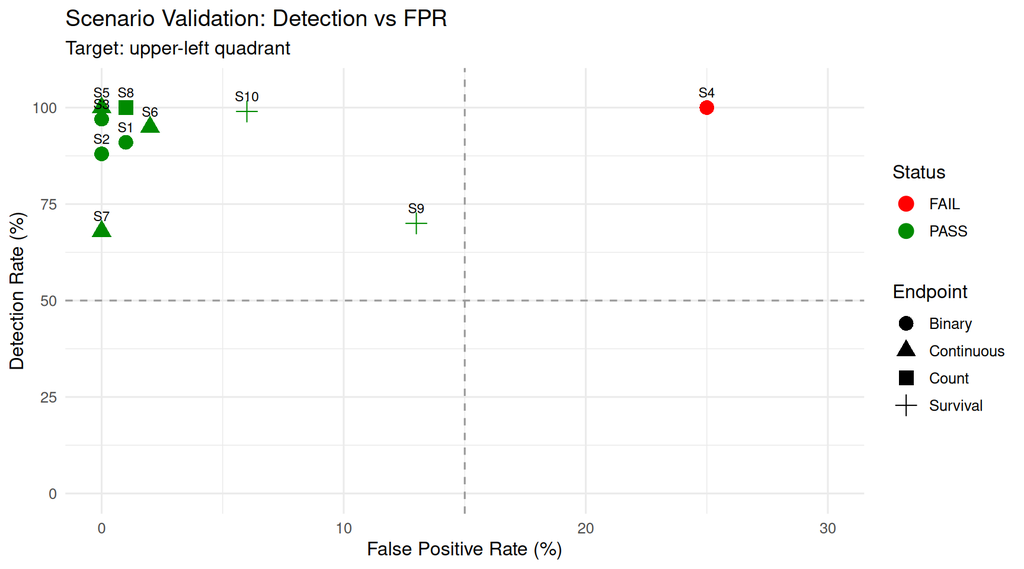

```r
if (nrow(master_results) > 0) {
  ggplot(master_results, aes(x = FPR_H0, y = Det_H1)) +
    geom_point(aes(colour = Status, shape = Endpoint), size = 4) +
    geom_text(aes(label = Scenario), vjust = -1, size = 3) +
    geom_hline(yintercept = 50, linetype = "dashed", colour = "grey60") +
    geom_vline(xintercept = 15, linetype = "dashed", colour = "grey60") +
    scale_colour_manual(values = c(
      PASS="green4", MARGINAL="orange", FAIL="red", ERROR="grey50")) +
    labs(x = "False Positive Rate (%)", y = "Detection Rate (%)",
         title = "Scenario Validation: Detection vs FPR",
         subtitle = "Target: upper-left quadrant") +
    coord_cartesian(
      xlim = c(0, max(25, max(master_results$FPR_H0, na.rm=TRUE)+5)),
      ylim = c(0, 105)) +
    theme_minimal(base_size = 12)
}
```

# 15 Timing Summary

```r
total_elapsed <- proc.time()[3]
cat(sprintf("Total document render time: %.1f minutes\n", total_elapsed / 60))
```

```
#> Total document render time: 4.5 minutes
```

```r
cat(sprintf("Workers used: %d\n\n", n_workers))
```

```
#> Workers used: 115
```

```r
if (nrow(timing_log) > 0) {
  # Add projections for 500 alt / 1000 null
  timing_log$proj_H1 <- round(timing_log$per_sim_H1 * 500, 1)
  timing_log$proj_H0 <- round(timing_log$per_sim_H0 * 1000, 1)
  timing_log$proj_total <- timing_log$proj_H1 + timing_log$proj_H0
  timing_log$proj_min <- round(timing_log$proj_total / 60, 1)

  timing_log |>
    gt::gt() |>
    gt::tab_header(
      title = "Timing Summary by Scenario",
      subtitle = sprintf(
        "Current run: %d alt + %d null sims, %d workers",
        nsims_alt, nsims_null, n_workers)
    ) |>
    gt::cols_label(
      time_H1 = "H1 (sec)",
      time_H0 = "H0 (sec)",
      per_sim_H1 = "Per Sim H1 (sec)",
      per_sim_H0 = "Per Sim H0 (sec)",
      proj_H1 = "H1 500 (sec)",
      proj_H0 = "H0 1000 (sec)",
      proj_total = "Total (sec)",
      proj_min = "Total (min)"
    ) |>
    gt::tab_spanner(
      label = "Current Run",
      columns = c("nsims_H1", "nsims_H0", "time_H1", "time_H0")
    ) |>
    gt::tab_spanner(
      label = "Per Simulation",
      columns = c("per_sim_H1", "per_sim_H0")
    ) |>
    gt::tab_spanner(
      label = "Projected: 500 alt / 1000 null",
      columns = c("proj_H1", "proj_H0", "proj_total", "proj_min")
    ) |>
    gt::tab_source_note(sprintf(
      "Projected total for 500/1000: %.1f minutes (%.1f hours)",
      sum(timing_log$proj_min), sum(timing_log$proj_min) / 60))
}
```

Timing Summary by Scenario

Current run: 100 alt + 100 null sims, 115 workers

| Scenario | Endpoint | Current Run nsims_H1 | Current Run nsims_H0 | Current Run H1 (sec) | Current Run H0 (sec) | Per Simulation Per Sim H1 (sec) | Per Simulation Per Sim H0 (sec) | Projected: 500 alt / 1000 null H1 500 (sec) | Projected: 500 alt / 1000 null H0 1000 (sec) | Projected: 500 alt / 1000 null Total (sec) | Projected: 500 alt / 1000 null Total (min) |
| --- | --- | --- | --- | --- | --- | --- | --- | --- | --- | --- | --- |
| S1 | Binary | 100 | 100 | 129.1 | 3.9 | 1.291 | 0.039 | 645.5 | 39 | 684.5 | 11.4 |
| S2 | Binary | 100 | 100 | 16.0 | 3.3 | 0.160 | 0.033 | 80.0 | 33 | 113.0 | 1.9 |
| S3 | Binary | 100 | 100 | 5.7 | 2.5 | 0.057 | 0.025 | 28.5 | 25 | 53.5 | 0.9 |
| S4 | Binary | 100 | 100 | 5.4 | 7.8 | 0.054 | 0.078 | 27.0 | 78 | 105.0 | 1.8 |
| S5 | Continuous | 100 | 100 | 4.5 | 2.3 | 0.045 | 0.023 | 22.5 | 23 | 45.5 | 0.8 |
| S6 | Continuous | 100 | 100 | 6.7 | 2.7 | 0.067 | 0.027 | 33.5 | 27 | 60.5 | 1.0 |
| S7 | Continuous | 100 | 100 | 3.8 | 2.4 | 0.038 | 0.024 | 19.0 | 24 | 43.0 | 0.7 |
| S8 | Count | 100 | 100 | 8.4 | 4.7 | 0.084 | 0.047 | 42.0 | 47 | 89.0 | 1.5 |
| S9 | Survival | 100 | 100 | 22.1 | 18.1 | 0.221 | 0.181 | 110.5 | 181 | 291.5 | 4.9 |
| S10 | Survival | 100 | 100 | 6.9 | 7.3 | 0.069 | 0.073 | 34.5 | 73 | 107.5 | 1.8 |

Projected total for 500/1000: 26.7 minutes (0.4 hours)

# 16 Conclusion

```r
n_pass <- sum(master_results$Status == "PASS")
n_total <- nrow(master_results)
n_fail <- sum(master_results$Status == "FAIL")

cat(sprintf("%d of %d scenarios passed.\n", n_pass, n_total))
```

```
#> 9 of 10 scenarios passed.
```

```r
if (n_fail > 0) {
  cat("\nScenarios with elevated FPR:\n")
  failed <- master_results[master_results$Status == "FAIL",
    c("Scenario", "Null_ITT", "FPR_H0")]
  print(failed, row.names = FALSE)
  cat("\nElevated FPR typically indicates the screening threshold\n")
  cat("is too close to the null ITT effect. The L_eff calibration\n")
  cat("procedure in the full simulation documents addresses this.\n")
}
```

```
#>
#> Scenarios with elevated FPR:
#>  Scenario Null_ITT FPR_H0
#>        S4  OR=0.90     25
#>
#> Elevated FPR typically indicates the screening threshold
#> is too close to the null ITT effect. The L_eff calibration
#> procedure in the full simulation documents addresses this.
```